# Doing Data Science

Thijs Leufkens

31-12-2016

## all packages which are needed

This post will describe the EDA (Exploratory Data Analysis) excercise from the Doing Data Science book by Cathy O’Neil & Rachel Schutt. The data represents a simulated day’s worth of ads shown and clicks recorded on the New York Times home page in May 2012.

```r
data1 <- read.csv(url("http://stat.columbia.edu/~rachel/datasets/nyt1.csv"))
```

## What’s in the dataset?

Let’s check how many columns / rows etc. there are and plot the first to rows to see some of its content with our own eyes.

```r
dim(data1)
```

```
## [1] 458441      5
```

```r
str(data1)
```

```
## 'data.frame':    458441 obs. of  5 variables:
##  $ Age        : int  36 73 30 49 47 47 0 46 16 52 ...
##  $ Gender     : int  0 1 0 1 1 0 0 0 0 0 ...
##  $ Impressions: int  3 3 3 3 11 11 7 5 3 4 ...
##  $ Clicks     : int  0 0 0 0 0 1 1 0 0 0 ...
##  $ Signed_In  : int  1 1 1 1 1 1 0 1 1 1 ...
```

```r
head(data1,2)
```

```
##   Age Gender Impressions Clicks Signed_In
## 1  36      0           3      0         1
## 2  73      1           3      0         1
```

The first excercise in the book is to create a new variable age_group to categorize the users. A quick search on Google provided a topic on stackoverflow explaining a method to do so. (http://stackoverflow.com/questions/12979456/r-code-to-categorize-age-into-group-bins-breaks)

```r
library(data.table)
agebreaks <- c(0,18,25,35,45,55,65,500)
agelabels= c("<18","18-24","25-34","35-44","45-54","55-64","65+")

## setDT(data1)[ , Age_Group:= cut(Age, breaks= agebreaks, right= FALSE, labels= agelabels)]
data1$Age_Group <- cut(data1$Age, breaks= agebreaks, right= FALSE, labels= agelabels)
```

Now that we have categorized users by age group, we can do some initial analysis to see if something stands out. We are interested in the click-through-rate (CTR = clicks / impressions). The assumption is that if we have a click without an impression, the data is wrong.

```r
data1$CTR <- data1$Clicks/data1$Impressions
```

Let’s plot the number of impressions and CTR for each age group:

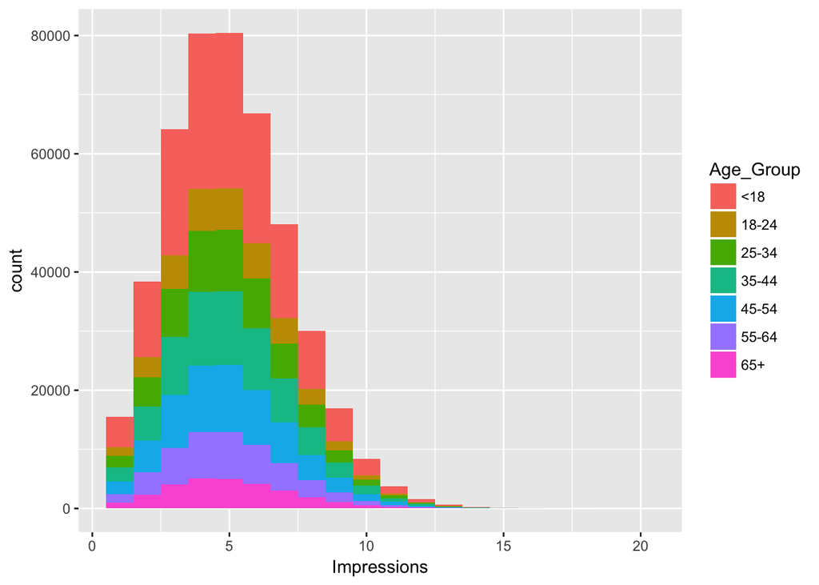

```r
library("tidyr")
library("ggplot2")


ggplot(subset(data1, Impressions>0), aes(x=Impressions, fill=Age_Group))+geom_histogram(binwidth = 1)
```

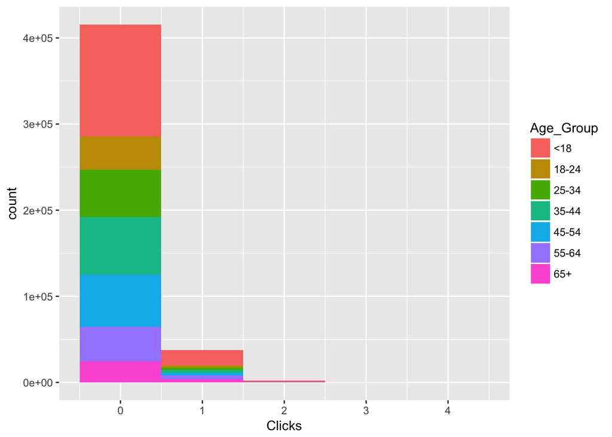

```r
ggplot(subset(data1, Impressions>0), aes(x=Clicks, fill=Age_Group))+geom_histogram(binwidth = 1)
```

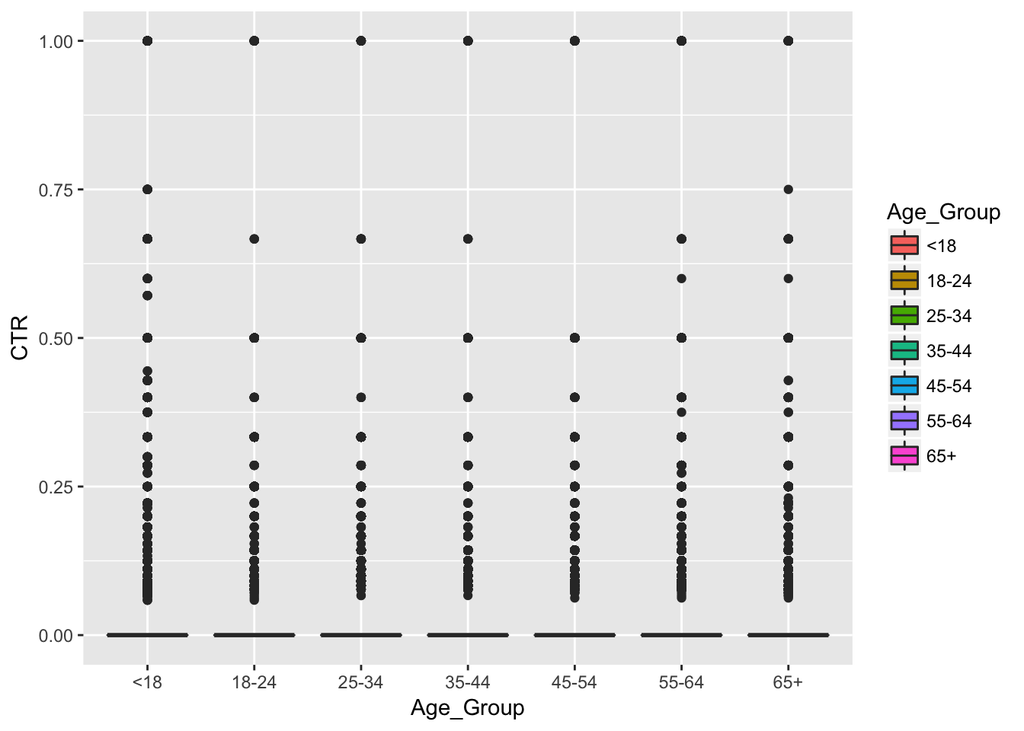

```r
ggplot(subset(data1, Impressions>0), aes(x=Age_Group, y = CTR, fill=Age_Group))+geom_boxplot()
```

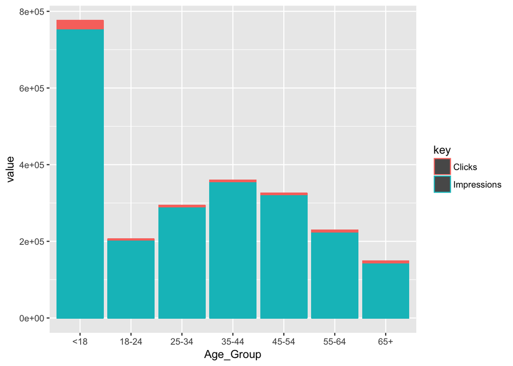

```r
subset(data1, Impressions>0) %>%
  gather(key, value, Impressions, Clicks) %>%
  ggplot(aes(x = Age_Group, y = value, colour=key)) + geom_bar(stat = "identity")
```

When we plot the number of clicks only, we notice something strange.

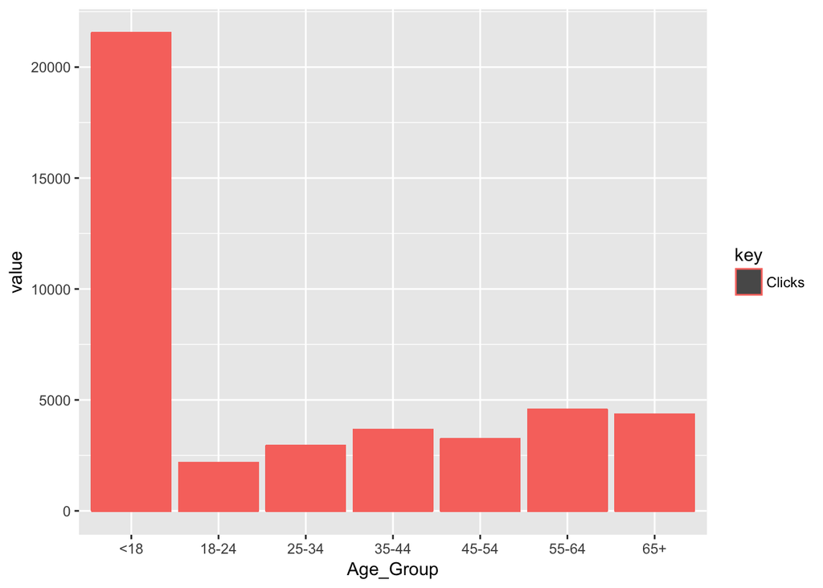

```r
subset(data1, Impressions>0) %>%
  gather(key, value, Clicks) %>%
  ggplot(aes(x = Age_Group, y = value, colour=key)) + geom_bar(stat = "identity")
```

The under 18 bucket seems to be an outlier, what’s going on here? Let’s compared signed in vs not signed in:

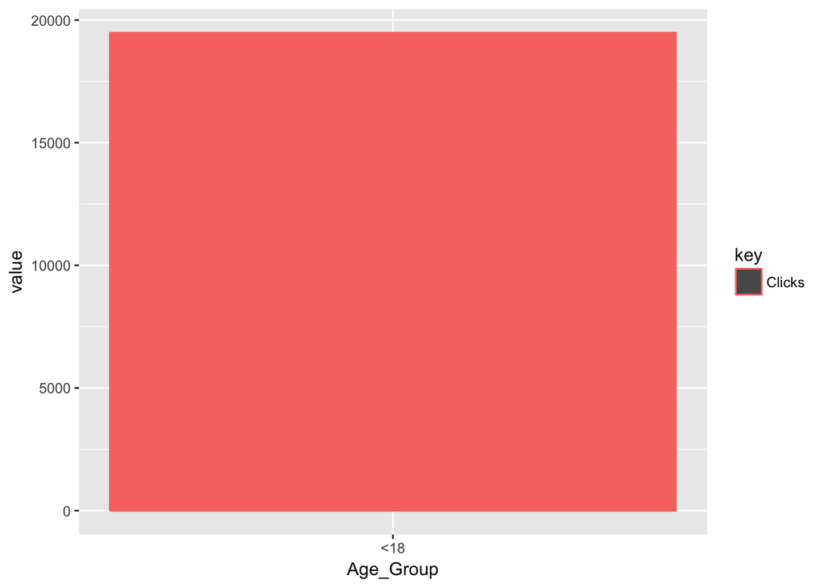

```r
subset(data1, Signed_In < 1) %>%
  gather(key, value, Clicks) %>%
  ggplot(aes(x = Age_Group, y = value, colour=key)) + geom_bar(stat = "identity")
```

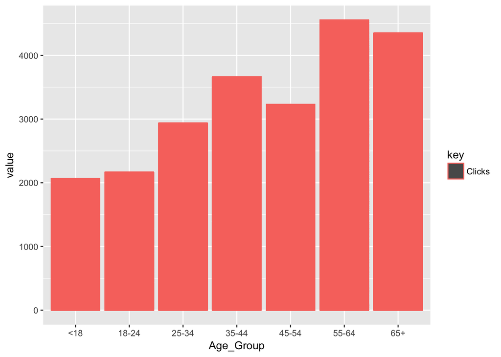

```r
subset(data1, Signed_In > 0) %>%
  gather(key, value, Clicks) %>%
  ggplot(aes(x = Age_Group, y = value, colour=key)) + geom_bar(stat = "identity")
```

Appartently the “not signed in” users are in the <18 bucket, let’s explore a bit furhter

```r
anonymousdata1 <- subset(data1, Signed_In < 1)
min(anonymousdata1$Age)
```

```
## [1] 0
```

```r
max(anonymousdata1$Age)
```

```
## [1] 0
```

```r
min(anonymousdata1$Gender)
```

```
## [1] 0
```

```r
max(anonymousdata1$Gender)
```

```
## [1] 0
```

```r
min(anonymousdata1$Impressions)
```

```
## [1] 0
```

```r
max(anonymousdata1$Impressions)
```

```
## [1] 18
```

```r
min(anonymousdata1$Clicks)
```

```
## [1] 0
```

```r
max(anonymousdata1$Clicks)
```

```
## [1] 4
```

As to be expected, no age and gender data exists for the anonymous users.

To conclude let’s plot some scatterplot matrices:

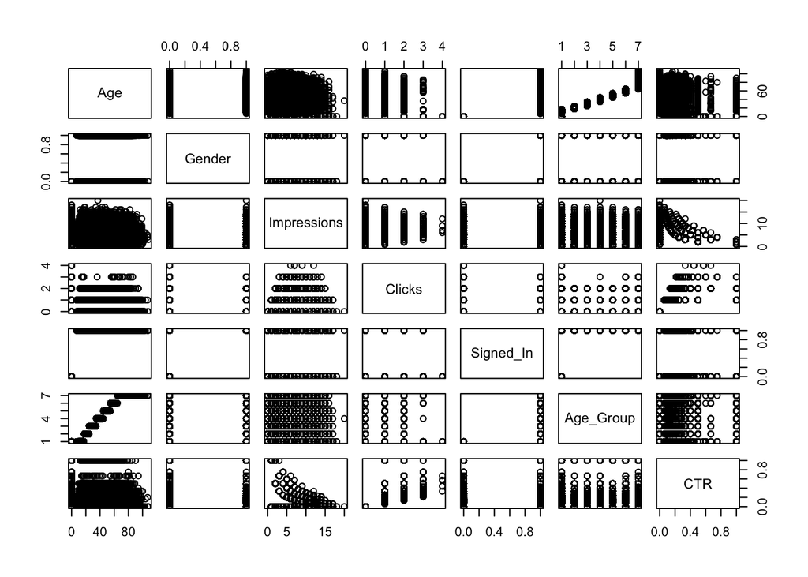

First impressions: This takes a long time to run! Age and Age_Group seem nicely correlated ;)